# Design Team Survey

Jake Rozran

2021-04-08

# Design Team Preferences

The design team, overall, prefers doing Design Strategy & Research and Interaction Design, followed closely with People Management. Less favored are Content Design and Visual Design.

This is not to say that these groups are universally liked or not liked. Within each area, there are specific preferences and dislikes.

## Overall Preferences

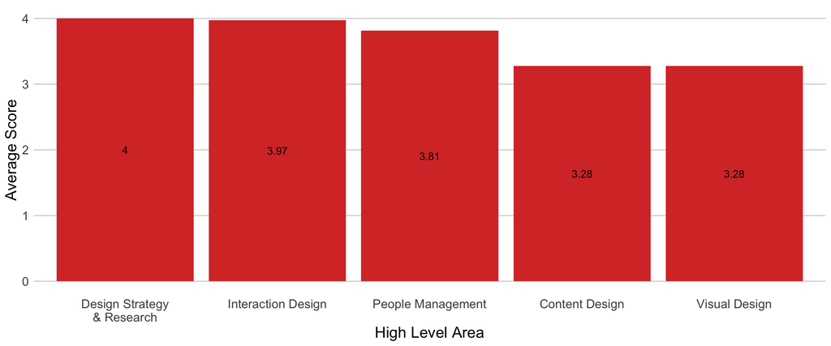

## Design Strategy & Research Preferences

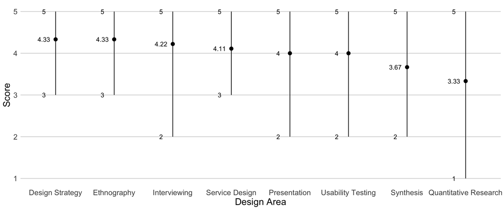

- **Point** represents the average preference score
- The confidence interval is bounded on the **lower end** with the minimum preference score
- The confidence interval is bounded on the **upper end** with the maximum preference score

## Visual Design Preferences

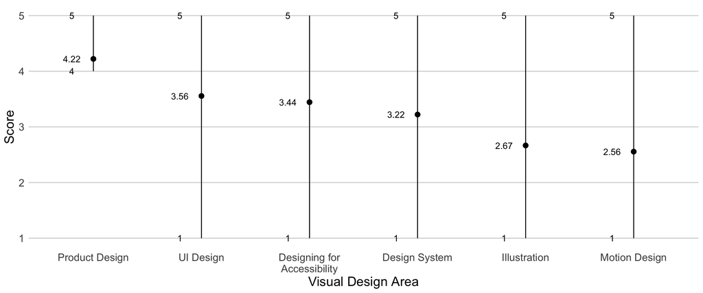

- **Point** represents the average preference score
- The confidence interval is bounded on the **lower end** with the minimum preference score
- The confidence interval is bounded on the **upper end** with the maximum preference score

## Interaction Design Preferences

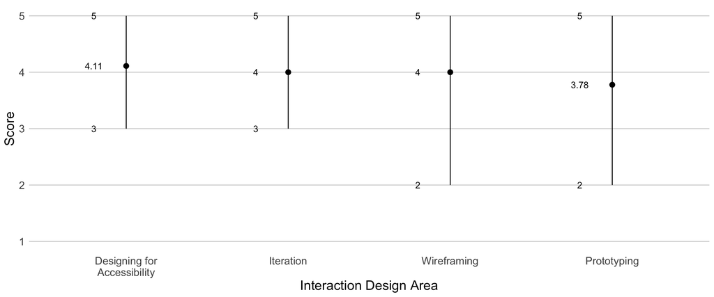

- **Point** represents the average preference score
- The confidence interval is bounded on the **lower end** with the minimum preference score
- The confidence interval is bounded on the **upper end** with the maximum preference score

## Content Design Preferences

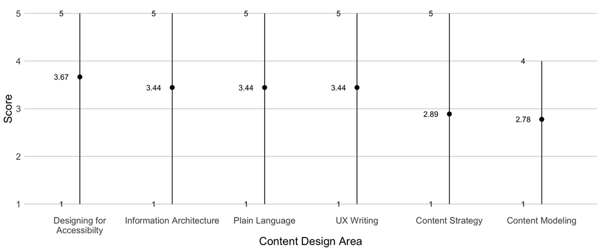

- **Point** represents the average preference score
- The confidence interval is bounded on the **lower end** with the minimum preference score
- The confidence interval is bounded on the **upper end** with the maximum preference score

## People Management Preferences

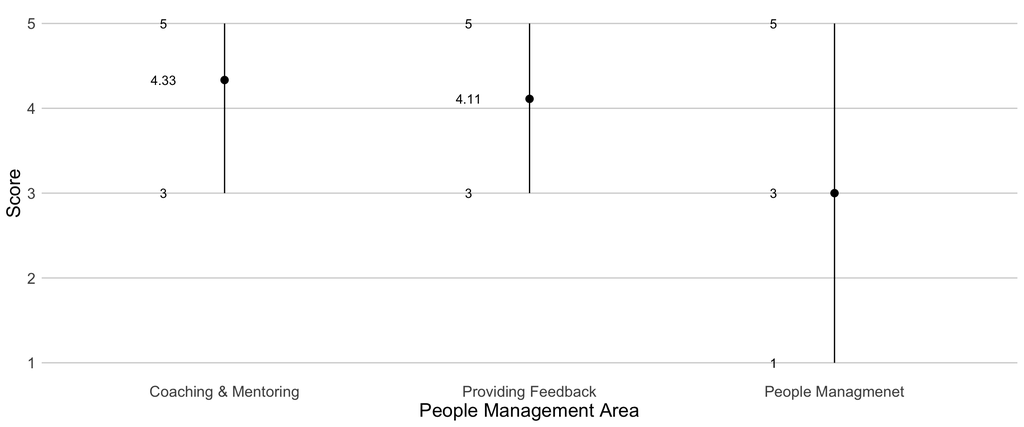

- **Point** represents the average preference score
- The confidence interval is bounded on the **lower end** with the minimum preference score
- The confidence interval is bounded on the **upper end** with the maximum preference score

# Individual Preferences

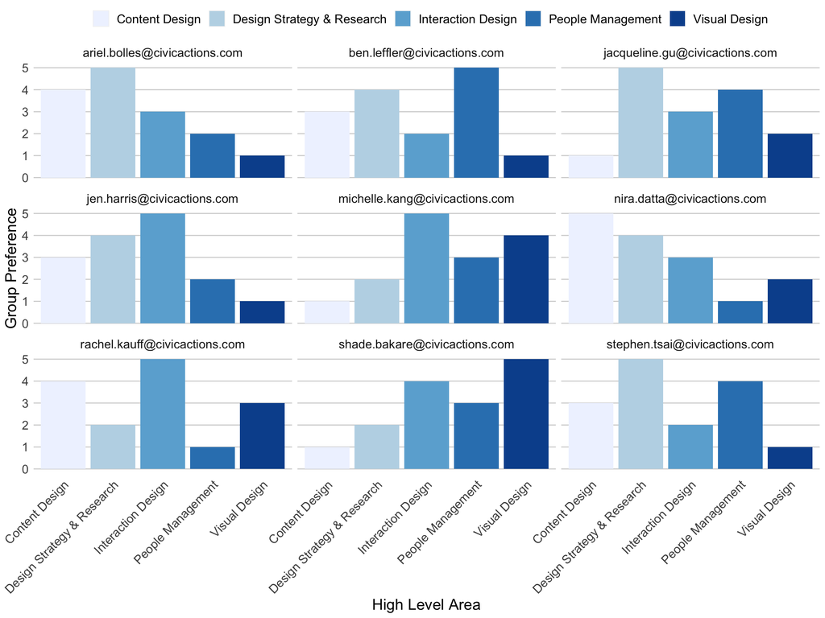

For each person, average score in each area was calculated and ranked. 5 is the highest rank for an individual and 1 is the lowest rank.

# High Level Areas & People Who Prefer Them

For each high level design area, who has this ranked their highest?

| Design Practice Area | People |
| --- | --- |
| Content Design | nira datta |
| Design Strategy & Research | ariel bolles \| jacqueline gu \| stephen tsai |
| Interaction Design | jen harris \| michelle kang \| rachel kauff |
| People Management | ben leffler |
| Visual Design | shade bakare |